# Dengue in Thailand: Predict the District Challenge

Nicholas Reich

September 10, 2017

This document contains the guidelines for a Reich Lab challenge of predicting dengue fever in Thailand at the district level.

## Challenge Overview

Through our collaboration with the Thai Ministry of Public Health (MOPH), we have curated a dataset containing over 2.5 million records of unique cases of dengue fever infections in Thailand since 1968. All of these records come from their national surveillance system. Thailand has 76 provinces, or “changwat” (plus one municipality, Bangkok) and close to 900 districts, or “amphoe”. Based on census data from 2002, districts have on average about 70,000 residents, although they range in size from about 2,000 to over 400,000.

Records of dengue fever are split into three categories, dengue fever (DF), dengue hemorrhagic fever (DHF), and dengue shock syndrome (DSS), representing different clinical manifestations of infection with dengue virus. DHF and DSS are severe forms of dengue that are often clinically attended. In our modeling to date, we have used records of DHF because it was the first of the three to become a notifiable disease, and reporting of DHF is likely more consistent over time since it is usually a hospital-attended illness.

Data were collected and reported in different ways over time. Prior to 1999, we have monthly province-level counts of DHF. After 1999, we have list-list data (one case per row) with detailed case-level information, including an address code that specifies province, district, subdistrict, and in some cases the village level.

## The Dataset

The primary dataset that we will use for this project contains counts of DHF at aggregated spatially the district level and temporally into biweeks (standard 14 or 15 day units of calendar time, see table at end of document). We have used biweeks in our work modeling dengue because two weeks is roughly the generation time of dengue fever (the time between subsequent human infections in a chain of transmission), making it an epidemiologically relevant unit of time. It has the added advantage (unlike a week, but similar to months) of having a clear definition relative to calendar time.

Here are the top few rows of the primary dataset which has 215488 total rows:

```
## # A tibble: 6 x 7
##   province district  year biweek cases  date_sick          prov_name
##      <dbl>    <chr> <int>  <int> <int>     <date>             <fctr>
## 1       10     1000  2006      1     0 2006-01-01 Bangkok Metropolis
## 2       10     1000  2006      2     0 2006-01-15 Bangkok Metropolis
## 3       10     1000  2006      3     0 2006-01-29 Bangkok Metropolis
## 4       10     1000  2006      4     0 2006-02-12 Bangkok Metropolis
## 5       10     1000  2006      5     0 2006-02-26 Bangkok Metropolis
## 6       10     1000  2006      6     0 2006-03-12 Bangkok Metropolis
```

Additional datasets will be available for use.

- Google query data for dengue-related terms from 2004 - 2016. Separate files for all of Thailand, Bangkok, and Chiang Mai.
- Serotype-specific incidence data from a Bangkok children’s hospital (1973-201X) [we have data in hand through 2012, hoping to get through 2016]
- Counts aggregated into province-biweeks will be provided for the same years as the overall challenge. These counts include a small number of cases that are part of the final MOPH dengue counts but do not have a district associated with their record.
- And teams should feel free to use other data that they feel might be relevant (i.e. climate data).

A training dataset, containing counts for the years 2006 - 2013 will be provided in the first phase of the project. A testing dataset with the years 2014-2016 will also be made available during the second phase of the project. See details below.

## Exploratory plots

The following plots show the district-level data. Specific provinces with high population, high average DHF incidence, or both are highlighted.

### All data

This plot shows training phase data for all districts in Thailand. The y-axis is sorted alpha-numerically, with the low numbers at the bottom. The bottom-most districts are Bangkok, which has the lowest province number of 10.

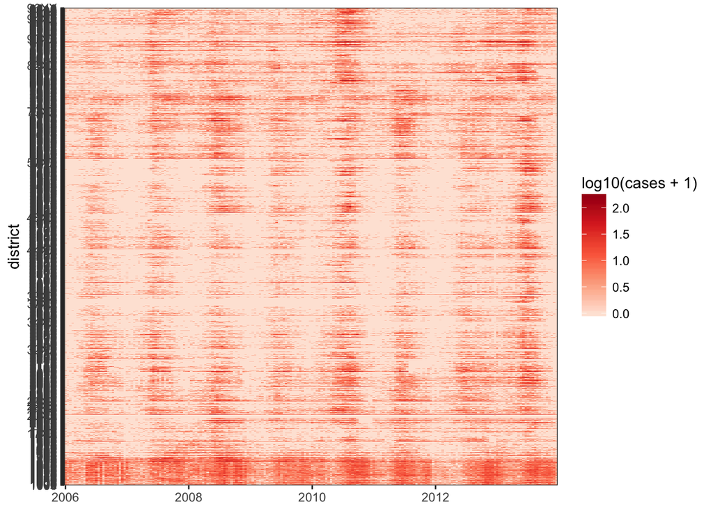

### Focal Provinces

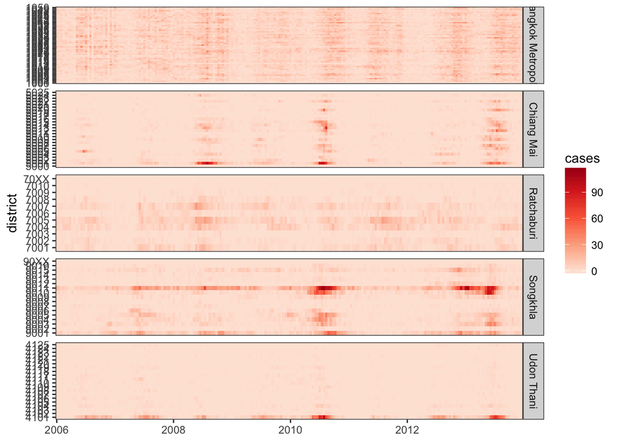

### Bangkok

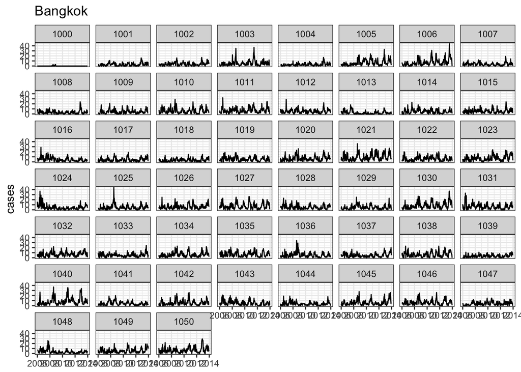

### Udon Thani

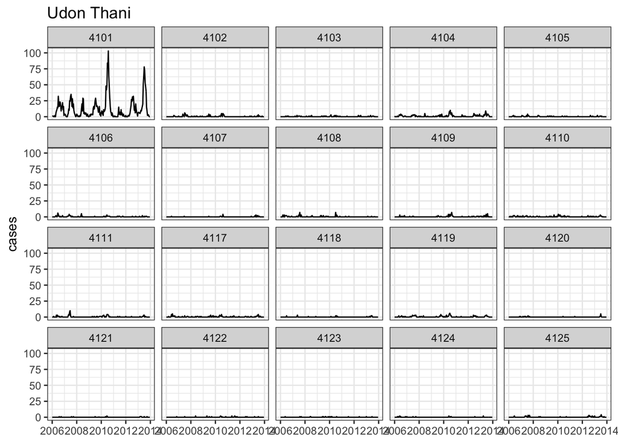

### Ratchaburi

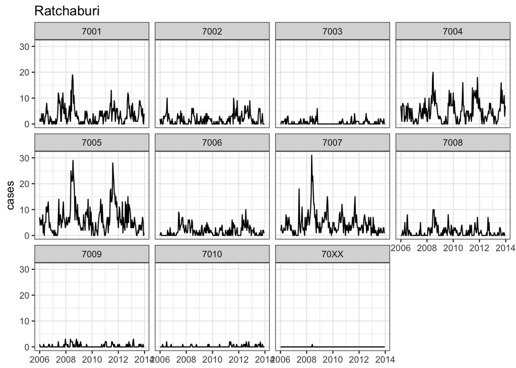

### Chiang Mai

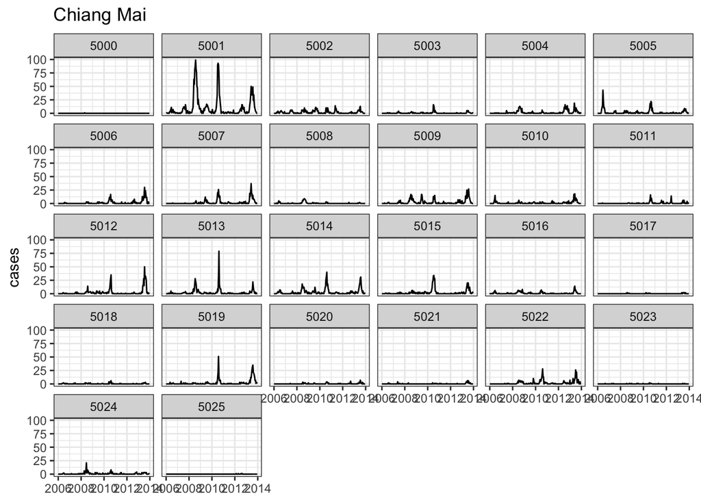

### Songkhla

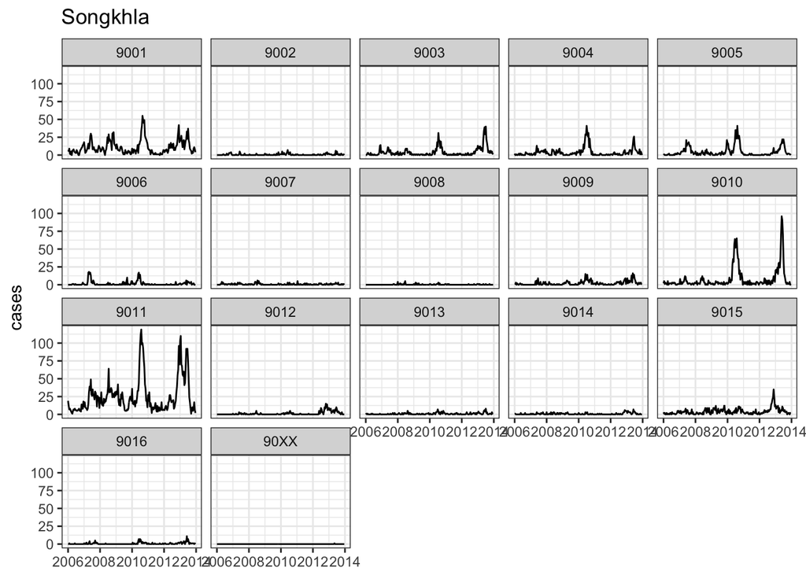

## Challenge Details

Each forecasting team member will create probabilistic forecasts using data provided above and any additional available data sources. The challenge is to construct a model or a set of models that can produce reasonable and repoducible forecasts for a set of district-level targets for each district in the provinces Bangkok, Songkhla, Chiang Mai, Udon Thani, and Ratchaburi. These five provinces were suggested by Dr. Sopon Iamsirithaworn as “of interest” and offering “benefit [to] dengue control strategists.”

### Submission format

This challenge will use the [`ForecastFramework` R package](https://github.com/HopkinsIDD/ForecastFramework) for model creation, validation, and evaluation. This package uses the R6 object-oriented syntax. Models are defined using a common syntax that wraps model-specific code for fitting, predicting, and forecasting data. Therefore, submissions will consist only of a `.R` model file. The challenge organizers will then apply these models to both training and testing datasets to obtain forecasts for an objective, indepenent, and pre-specified evaluation.

### Timeline

- June 2017: challenge announced and disseminated to Reich Lab
- October 16, 2017: Lab meeting presentations of model progress
- December 22, 2017: Model files due
- February 26, 2018: preliminary model performance report at lab meeting

### Forecasting targets

Each model will be asked to predict a set of “targets” that represent quantities of public health relevance and that can be predicted at any time throughout the year. For each district at biweek $t$ in a given year, we are interested in forecsts for:

1. The number of reported cases in each of the following 10 biweeks. If data is observed through time $t$ then forecasts for times $t+1$, …, $t+10$ will be handed in. If time $t$ falls within 10 biweeks of the end of the calendar year, still, the forecast should include 10 biweeks into the future.
2. The total number of reported cases for that calendar year. Unlike the biweekly incidence targets, this target is a single scalar value; the target does not change throughout the year.
3. Peak number of reported cases in a single biweek for that calendar year. Unlike the biweekly incidence targets, this target is a single scalar value; the target does not change throughout the year.
4. The biweek in which the peak incidence will occur. This is the only target whose set of units are not based on case incidence. The predictive distribution here is a discrete distribution that can take values between 1 and 26.

The expectation is that each team’s model will be capable of producing predictions for each target, although exceptions can be made by request.

### Training set

Initially, each team will be given a dataset containing the integer numer of confirmed DHF cases reported in each district for each biweek in the years 2006 through 2013. This will be considered the “training set” of data. Teams may use the training dataset to train different models and compare performance, however ultimately only 1-2 model file(s) may be submitted per team.

During the evaluation phase, forecasts will always be made prospectively, meaning that only data in the past will be used to fit models and forecast for times in the future.

To follow the “best practices” for creating predictions, teams are encouraged to fit and generate forecasts from multiple different models in the training period. However, a maximum of two models’ forecasts may be submitted. Using cross-validation, multiple models may be tested and compared to each other in the training phase. This will provide an estimate of the predictive performance of each model in the testing phase. In our (and others’) previous prediction work, we have seen simple models that perform slightly worse than a more complicated model in the training phase show stronger performance in the testing phase. This can reflect “overfitting” (or getting lucky) in the training phase, which, given that we have a relatively small number of training seasons, is likely to be a factor.

### Test set

Once the training set forecasts are submitted, organizers will run all models and create prospective forecasts for both the training phase and the test phase.

### Submission format

A “forecast submission” refers to a valid model file. Specific checks and tests will be implemented in fall 2017. More detail on these will be forthcoming.

#### Submissions

A complete submission will include two files: a metadata file describing the model as well as the model file itself. The model file should be named using SentenceCase (e.g. “MyModel.R”) and the metadata file should be a `.txt` file with the same name as the model file with “-metadata” appended before the file prefix, e.g. “MyModel-metadat.txt”. Some templates for the submission materials are available in the [models folder on the GitHub repository](https://github.com/reichlab/thai-dengue-district-challenge/tree/master/models).

1. Metadata file

This will include the following fields:

- Model name
- Model abbreviation for submission files
- Authors
- Brief description of data sources
- Brief methodological description
2. The model file

This model should be a valid ForecastFramework model. More details on the checks that will be put in place will be forthcoming.

## Ensemble model

After training set forecasts are submitted, we will estimate parameters for an ensemble model that will be used to fuse the forecasts from each model into a single forecast. We will use a variation on the feature-weighted density ensemble approach described [here](https://arxiv.org/abs/1703.10936).

The ensemble will be used in the test phase to generate predictions. Specifically, it will use the leave-one-season-out forecasts from the training phase to estimate weights and generate predictions for 2014; it will incorporate the prospective test-phase forecasts for component models in 2014 with the leave-one-season-out forecasts to estimate weights and generate predictions for 2015; etc…

### Ensemble model weights

The feature-weighted density ensemble will include the following features in estimation for the test-phase forecasts, separately for each target:

- by location, horizon, and biweek
- by location and horizon
- by location and biweek
- by horizon and biweek
- by location
- by horizon
- by biweek

Estimated weights over horizon and biweek will be smoothed. The horizon feature is only applicable for the biweekly incidence targets. When location is included in the ensemble, the estimation will occur separately for each location. When only location is included, the degenerate EM algorithm will be used for estimation.

Additional simpler ensembles will also include:

- a simple weighted average of all models.
- a weighted average that is the same for all targets but different by location.

## Pre-specified analyses/scoring

For each model individually (including ensemble specifications):

- the test set average log score for each metric
- the test set log score 5th/25th/50th/75th/95th percentiles for each metric
- the test set MAE for peak and total annual incidence
- the test set MAE 5th/25th/50th/75th/95th percentiles for peak and total annual incidence
- the test set average log score across all metrics
- difference between training set vs test set average log score

By district:

- the test set average log score by horizon will be compared (via correlation?) to a metric of predictability computed on the training set data

Over all districts and models:

- regression model to estimate significant differences between models
- specific suggested analysis by reviewer 2 in KCDE paper (Diebold-Mariano test (see Gneiting and Katzfuss, 2014))

## Working participant and model list

| team member | model/method |
| --- | --- |
| Casey | Gaussian Processes |
| Steve | annual GAM |
| Kristina | Prophet |
| Coco | SARIMA? + Google |
| John G | Hierarchical/state space |
| … | … |

When the training and test set forecasts are uploaded, we will also create a visualization repository using `d3-foresight` to interactively visualize the forecasts, similar to the current [FluSight](http://reichlab.io/flusight) app.

## Appendix: Definition of biweeks

The following table is a map of Julian calendar days to biweeks used in data aggregation. Columns show the date a biweek starts and the duration for non-leap (``reg’’) and leap years.

| biweek | reg_yr_datestart | reg_yr_dur | leap_yr_datestart | leap_yr_dur |
| --- | --- | --- | --- | --- |
| 1 | Jan 01 | 14 | Jan 01 | 14 |
| 2 | Jan 15 | 14 | Jan 15 | 14 |
| 3 | Jan 29 | 14 | Jan 29 | 14 |
| 4 | Feb 12 | 14 | Feb 12 | 14 |
| 5 | Feb 26 | 14 | Feb 26 | 15 |
| 6 | Mar 12 | 14 | Mar 12 | 14 |
| 7 | Mar 26 | 14 | Mar 26 | 14 |
| 8 | Apr 09 | 14 | Apr 09 | 14 |
| 9 | Apr 23 | 14 | Apr 23 | 14 |
| 10 | May 07 | 14 | May 07 | 14 |
| 11 | May 21 | 14 | May 21 | 14 |
| 12 | Jun 04 | 14 | Jun 04 | 14 |
| 13 | Jun 18 | 14 | Jun 18 | 14 |
| 14 | Jul 02 | 14 | Jul 02 | 14 |
| 15 | Jul 16 | 14 | Jul 16 | 14 |
| 16 | Jul 30 | 14 | Jul 30 | 14 |
| 17 | Aug 13 | 14 | Aug 13 | 14 |
| 18 | Aug 27 | 14 | Aug 27 | 14 |
| 19 | Sep 10 | 14 | Sep 10 | 14 |
| 20 | Sep 24 | 14 | Sep 24 | 14 |
| 21 | Oct 08 | 14 | Oct 08 | 14 |
| 22 | Oct 22 | 14 | Oct 22 | 14 |
| 23 | Nov 05 | 14 | Nov 05 | 14 |
| 24 | Nov 19 | 14 | Nov 19 | 14 |
| 25 | Dec 03 | 14 | Dec 03 | 14 |
| 26 | Dec 17 | 15 | Dec 17 | 15 |